# Using the ReIns package

## Approximations using orthogonal polynomials

Based on the theory of orthogonal polynomial expansions, the normal approximation can be improved. The **Gram-Charlier approximation** (`pGC`) is an improvement of the normal approximation using Hermite polynomials. Another commonly used approximation is the **Edgeworth expansion** (`pEdge`).

Denote the standard normal PDF and CDF respectively by $\phi$ and $\Phi$. Let $\mu$ be the first moment, $\sigma^2=E((X-\mu)^2)$ the variance, $\mu_3=E((X-\mu)^3)$ the third central moment and $\mu_4=E((X-\mu)^4)$ the fourth central moment of the random variable $X$. The corresponding cumulants are given by $\kappa_1=\mu$, $\kappa_2=\sigma^2$, $\kappa_3=\mu_3$ and $\kappa_4=\mu_4-3\sigma^4$. Now consider the random variable $Z=(X-\mu)/\sigma$, which has cumulants 0, 1, $\nu=\kappa_3/\sigma^3$ and $k=\kappa_4/\sigma^4=\mu_4/\sigma^4-3$.

The **Gram-Charlier approximation** (`pGC`) for the CDF of $X$ is given by
$$\hat{F}_{GC}(x) = \Phi(z) + \phi(z) (-\nu/6
h_2(z)- k/24h_3(z))$$
with $h_2(z)=z^2-1$, $h_3(z)=z^3-3z$ and $z=(x-\mu)/\sigma$.

The **Edgeworth expansion** (`pEdge`) for the CDF of $X$ is given by
$$\hat{F}_{E}(x) = \Phi(z) + \phi(z) (-\nu/6
h_2(z)- (3k \times h_3(z)+\nu^2h_5(z))/72)$$
with $h_2(z)=z^2-1$, $h_3(z)=z^3-3z$, $h_5(z)=z^5-10z^3+15z$ and $z=(x-\mu)/\sigma$.

Both approximations need the first four raw moments as input when `raw=TRUE` or otherwise the mean, variance, skewness coefficient and kurtosis. Applying the two approximations to the same chi-squared sample as before gives following plot.

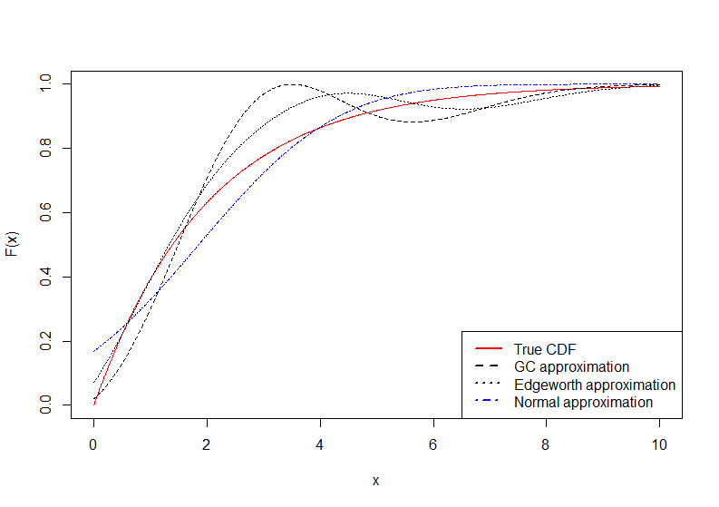

```r
x <- seq(0, 10, 0.01)

# Empirical moments
moments = c(mean(X), mean(X^2), mean(X^3), mean(X^4))

# Gram-Charlier approximation
p1 <- pGC(x, moments)

# Edgeworth approximation
p2 <- pEdge(x, moments)

# Normal approximation
p3 <- pClas(x, mean(X), var(X))

# True probabilities
p <- pchisq(x, 2)


# Plot true and estimated probabilities
plot(x, p, type="l", ylab="F(x)", ylim=c(0,1), col="red")
lines(x, p1, lty=2)
lines(x, p2, lty=3)
lines(x, p3, lty=4, col="blue")

legend("bottomright", c("True CDF", "GC approximation",
                        "Edgeworth approximation", "Normal approximation"),
       col=c("red", "black", "black", "blue"), lty=1:4, lwd=2)
```

# References

Albrecher, Hansjörg, Jan Beirlant, and Jef Teugels. 2017. *Reinsurance: Actuarial and Statistical Aspects*. Wiley, Chichester.

Beirlant, Jan, Yuri Goegebeur, Johan Segers, and Jef Teugels. 2004. *Statistics of Extremes: Theory and Applications*. Wiley, Chichester.